# Python-RPA環境構築-スプレッドシート編

まず初めに、RPAモジュールをインストールしましょう。

$`pip install fepr-py-rpa`

## Google Sheets API v4 トークン発行

それでは次に認証情報を作ります。

**[Quick Start](https://developers.google.com/sheets/api/quickstart/python?hl=ja)**を開いて、**ENABLE THE GOOGLE SHEETS API**をクリックします。

[figure not shown]

次にプロジェクトを作成します。

今回のプロジェクト名は、『**`Python-RPA`**』で作成します。

プロジェクト名を入れたら**`NEXT`**ボタンをクリックして、次に進みます。

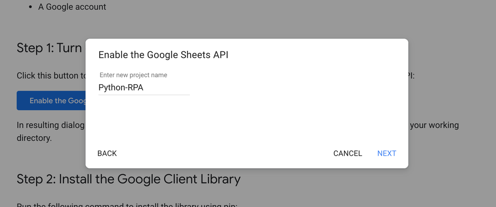

次に、『**`Desktop app`**』を選択し、**`CREATE`**ボタンをクリックします。

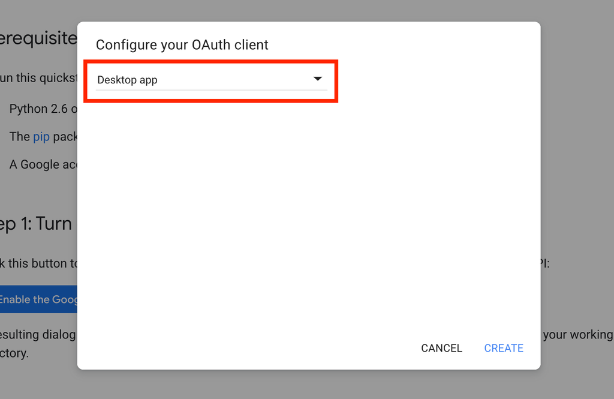

ダウンロードボタンをおして、jsonファイルを保存します。

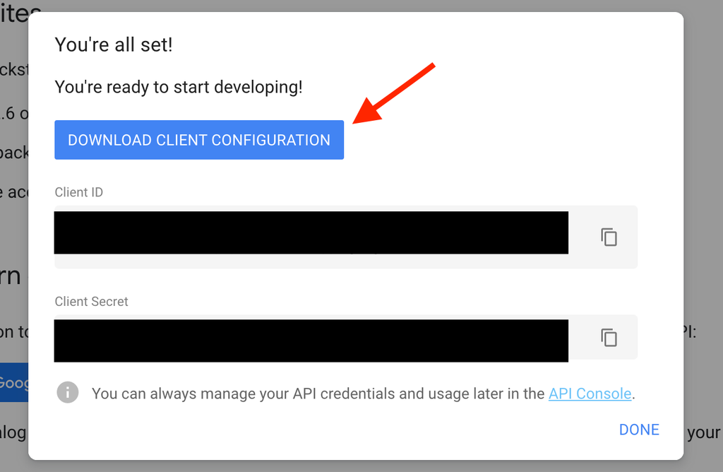

次に、実行するjupyterファイル、もしくはPythonファイルと同じディレクトリに先ほどDLした『**`credentials.json`**』を移動させます。

[figure not shown]

そうしたら、下のスクリーンショットと同じコードを入力し、実行します。

[figure not shown]

実行すると、次のような認証画面に遷移するので、`json`ファイルを発行した時と同じGoogleアカウントを選択し、許可ボタンをクリックします。

[figure not shown]

[figure not shown]

そうすると、先程のディレクトリに新しく『**`token.pickle`**』というファイルが新しく生成されます。

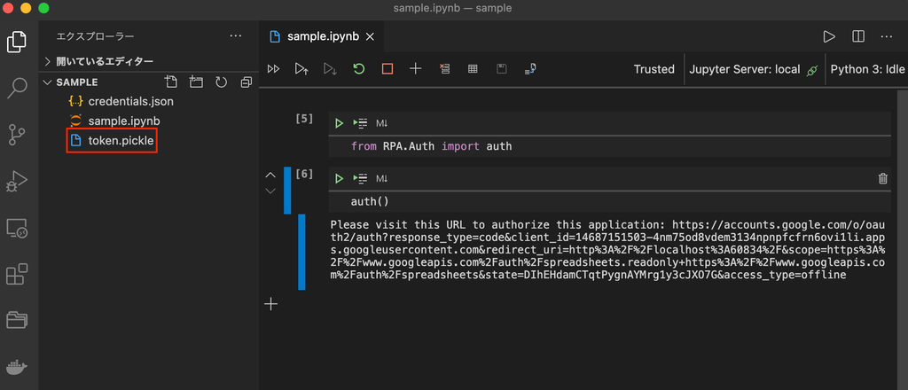

試しに、下記コードを実行してシート名を取得してみましょう。

```python
from RPA.Google.Spreadsheet import Spreadsheet

ss_id = "取得したいスプレドシートID"
sample_sheet = Spreadsheet(ss_id)
print(sample_sheet.load_metadata())
```

シート名と、シートidが取得できれば成功です。